# Lab 10: Poisson and Negative Binomial Models

Eric Parajon

Code has been adapted from Simon Hoellerbauer and Isabel Laterzo.

Load necessary packages:

```r
knitr::opts_chunk$set(echo = TRUE, messsage = FALSE)
rm(list=ls())

#Load in packages
pacman::p_load(tidyverse,
               haven,#for importing data
               labelled,
               MASS,
               AER,
               foreign,
               countreg,
               cowplot)
```

### Poisson and Negative Binomial Models

We can apply the types of exercises we’ve used for logits and multinomial logits to poisson models.

First, get our data. These data are counts from Maoz (2006) of interstate war.

(These data are available on Sakai.)

We’ll be using the variable “nowars20” as our DV - this counts the number of wars in the international system. Let’s plot a histogram:

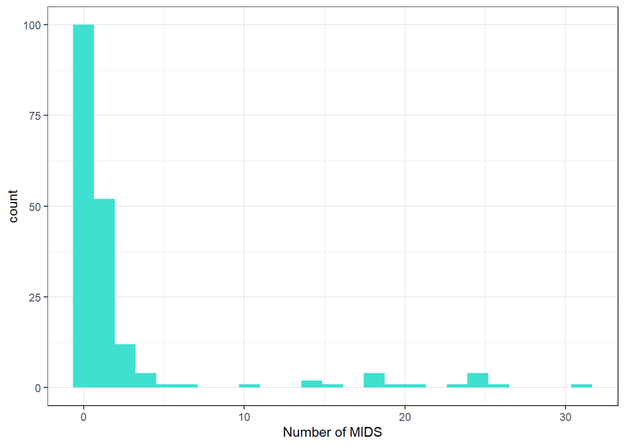

```r
ggplot(data = count , aes(x= nowars20 )) +
  geom_histogram(bins=25, fill="turquoise") +
  labs(x="Number of MIDS") +
  theme_bw()
```

This variable is an interesting one in that it’s possibly a bit larger (higher range of counts) than many we’d encounter.

Nonetheless, let’s build our model. We’re going to look at the number of militarized interstate wars based on ‘trade network polarization’ (lgtrdnpi2) and the number of democratic cliques (clqdemreg) in the system: Since we’re using count data what should the family argument be?

```r
m1 <- glm(nowars20 ~ lgtrdnpi2 + clqdemreg,
          data = count,
          family = "poisson")
summary(m1)
```

```
##
## Call:
## glm(formula = nowars20 ~ lgtrdnpi2 + clqdemreg, family = "poisson",
##     data = count)
##
## Deviance Residuals:
##     Min       1Q   Median       3Q      Max
## -3.6641  -2.3171  -1.5162  -0.9497  10.5572
##
## Coefficients:
##             Estimate Std. Error z value Pr(>|z|)
## (Intercept)   2.7016     0.1482  18.234   <2e-16 ***
## lgtrdnpi2    -9.1513     1.0673  -8.574   <2e-16 ***
## clqdemreg    -5.4620     0.5480  -9.968   <2e-16 ***
## ---
## Signif. codes:  0 '***' 0.001 '**' 0.01 '*' 0.05 '.' 0.1 ' ' 1
##
## (Dispersion parameter for poisson family taken to be 1)
##
##     Null deviance: 1182.2  on 126  degrees of freedom
## Residual deviance: 1038.3  on 124  degrees of freedom
##   (60 observations deleted due to missingness)
## AIC: 1222.9
##
## Number of Fisher Scoring iterations: 7
```

Note that this tells us “Dispersion parameter for poisson family taken to be 1.”

So, our constant gives the prediction if all X variables at zero (not always substantively meaningful, since some variables are not/cannot be 0).

The coefficient of each x is the expected difference in y (on the logarithmic scale) for each additional unit of the X. To interpret coefficients, we can exponentiate them and treat them as multiplicative effects.

Before we delve further into this model, we might want to check for overdispersion (what’s this?).

One approach is to plot the mean of the data against the estimated variance. Try doing this by using the `fitted()` function below (look up what it is!), and then following the code.

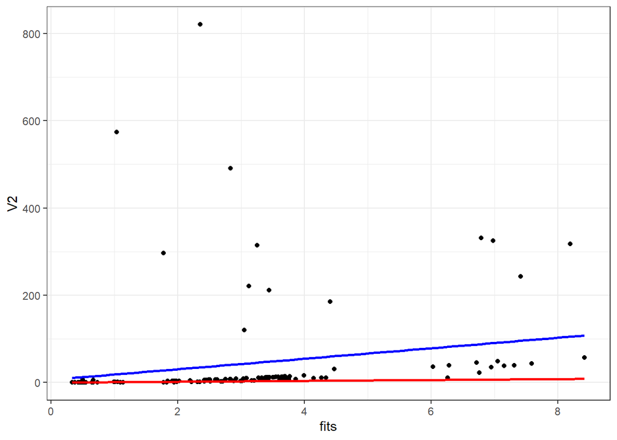

```r
fits <- fitted(m1) #fitted()

over <- data.frame(cbind(fits, (model.frame(m1)$nowars20-fits)^2)) #Use squared residuals to approx. value of the variance

ggplot(data=over, aes(x=fits, y=V2))+
  geom_point()+
  geom_smooth(aes(x=fits, y=V2), method=lm, se=FALSE, color="blue")+ #line for mean of estimates against the variance of estimates
  geom_smooth(aes(x=fits, y=fits), method=lm, se=FALSE, color='red')+ #assumes mean = variance
  theme_bw()
```

```r
  #Add legend
```

We can also check with the dispersiontest() in the AER package:

```r
dispersiontest(m1)
```

```
##
##  Overdispersion test
##
## data:  m1
## z = 2.7852, p-value = 0.002674
## alternative hypothesis: true dispersion is greater than 1
## sample estimates:
## dispersion
##   15.70482
```

So, our ALTERNATIVE hypothesis is that the true dispersion is greater than 1. What is our p-value? Do we reject the null? (What is the null?)

— don’t look  
— don’t look  
— don’t look  
— don’t look  
— don’t look  
— don’t look  
— don’t look  
— don’t look  
— don’t look  
— don’t look  
— don’t look

YES! Looks like we might be dealing with some overdispersion. What can we do to correct this? Let’s try a new model - a negative binomial model. While Poisson assumes that the mean and variance are the same, the Negative Binomial model better fits data that shows variation which is greater than the mean. The NB model has an additional parameter compared to the Poisson, and this parameter allows us to adjust for more dispersion in the data. In fact, the Poisson model is a special case of the NB.

The `glm` function does not handle NB models. We now need to use a new function - `glm.nb` - which is especially for NB models.

```r
m2<- MASS::glm.nb(nowars20 ~ lgtrdnpi2 + clqdemreg,
            data = count)
summary(m2)
```

```
##
## Call:
## MASS::glm.nb(formula = nowars20 ~ lgtrdnpi2 + clqdemreg, data = count,
##     init.theta = 0.2576310461, link = log)
##
## Deviance Residuals:
##     Min       1Q   Median       3Q      Max
## -1.2711  -1.1263  -0.6884  -0.3945   2.6493
##
## Coefficients:
##             Estimate Std. Error z value Pr(>|z|)
## (Intercept)   2.3463     0.5717   4.104 4.06e-05 ***
## lgtrdnpi2    -6.8139     3.7311  -1.826   0.0678 .
## clqdemreg    -4.4331     1.3877  -3.195   0.0014 **
## ---
## Signif. codes:  0 '***' 0.001 '**' 0.01 '*' 0.05 '.' 0.1 ' ' 1
##
## (Dispersion parameter for Negative Binomial(0.2576) family taken to be 1)
##
##     Null deviance: 121.89  on 126  degrees of freedom
## Residual deviance: 111.29  on 124  degrees of freedom
##   (60 observations deleted due to missingness)
## AIC: 476.67
##
## Number of Fisher Scoring iterations: 1
##
##
##               Theta:  0.2576
##           Std. Err.:  0.0428
##
##  2 x log-likelihood:  -468.6720
```

```r
coefs<-cbind(coef(m1), coef(m2))
coefs
```

```
##                  [,1]      [,2]
## (Intercept)  2.701618  2.346344
## lgtrdnpi2   -9.151337 -6.813913
## clqdemreg   -5.462049 -4.433117
```

What happened to the coefficients?

We also can look at AIC - let’s compare the two models:

```r
#compare models using AIC
#which is better?

AIC(m1)
```

```
## [1] 1222.857
```

```r
AIC(m2)
```

```
## [1] 476.6724
```

```r
#AIC in m2 is lower
```

Let’s also compare these models using a rootogram. We’re going to install a package here from a repo which makes it easy to do this. Rootograms help us understand the predictive accuracy of a model based on actual data. It will show us the expected counts given the model vs. the observed counts. It does so by square rooting the counts, which allows us to more easily examine departures from our expectations even at smaller frequencies.

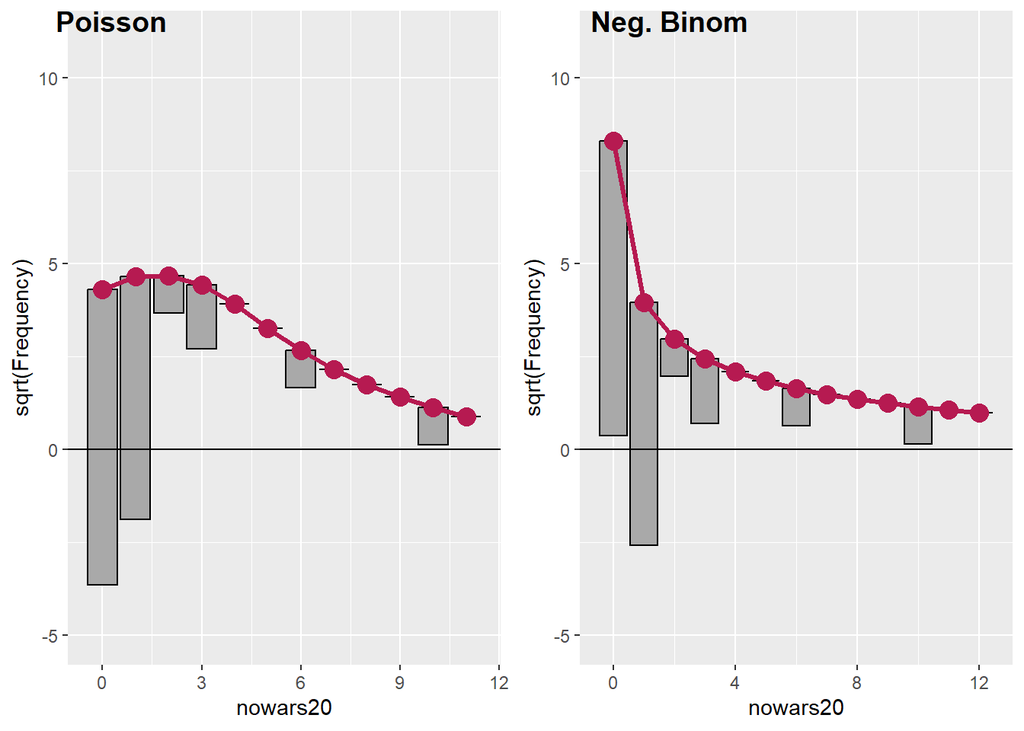

```r
#install.packages("countreg", repos="http://R-Forge.R-project.org")

library(countreg)
library(cowplot)

root.pois <- rootogram(m1, style = "hanging", plot = FALSE)
root.nb <- rootogram(m2, style = "hanging", plot = FALSE)

ylims <- ylim(-5, 11)  # common scale for comparison
#Using cowplot to put plots together with labels
plot_grid(autoplot(root.pois) + ylims, autoplot(root.nb) + ylims,
          ncol = 2, labels = c("Poisson", "Neg. Binom"))
```

What does this tell us?

The rootogram reflects fitted counts. If a bar doesn’t reach the zero line, the model is overpredicting a certain count bin. If it exceeds the zero line, it underpredicts. So, neither of these models are perfect. BUT - the poisson model seems to both over and underpredict a lot. The negative binomial model on the other hand definitely over predicts, but not as much.

## Predicted Counts

For the sake of illustration (and because we see it is a better fitting model), let’s use the NB model to plot predicted counts, using simulation.

```r
set.seed(8970)
Betas <- m2$coefficients
vcv <- vcov(m2)

#Set a number of simulations.
m2_sims <-1000

#Create our matrix of simulated data- we'll limit our dataset to do so.
sims_mat <- mvrnorm(m2_sims, Betas, vcv)
dim(sims_mat)
```

```
## [1] 1000    3
```

```r
temp_data <- model.matrix(m2)

pc_sims <- matrix(NA, nrow = m2_sims, ncol = nrow(temp_data))

#Fill in our predicted probabilities with a for() loop!
for(i in 1:m2_sims){
  pc_sims[i, ] <- exp(temp_data%*%sims_mat[i, ])
}

#What if we wanted a single point estimate of our predicted count of wars given our IVs?
mean<-mean(pc_sims)

#And the upper and lower boundaries of a confidence interval based on this simulation?
lower<-quantile(pc_sims, prob= 0.025)
upper<-quantile(pc_sims, prob= 0.975)

#putting it together
mapply(c,mean,lower,upper)
```

```
##           [,1]
## [1,] 3.1118040
## [2,] 0.4225063
## [3,] 7.8899812
```

How do we predict counts over the range of a variable? Like we always have! Let’s say we want to know what happens to the predicted number of counts as the average number of democratic cliques varies from its min to its max.

```r
#Re-naming count df to temp_data for use in this
temp_data <- count

dem_cl <- seq(from = min(count$clqdemreg, na.rm = T),
              to = max(count$clqdemreg, na.rm = T),
              length.out = 50)

#Using map_dfr to directly binds the rows to df we're calling pc_dem_cl
pc_dem_cl <- purrr::map_dfr(dem_cl, function(x){

  temp_data$clqdemreg <- x

  pc_df <- exp(model.matrix(m2, data = temp_data) %*% t(sims_mat))

  pc_val <- as.data.frame(t(colMeans(pc_df)))

})

#we could do this in one step, but I like keeping all of the simulated counts so
#we can do whatever we want with the distribution of predicted counts

plot_data <- t(apply(pc_dem_cl, 1, quantile, probs = c(.1, .5, .9))) %>% as.data.frame()
plot_data$dem_cl <- dem_cl

#So this give us the average point estimate (expected count), the low bound of a confidence interval, and the high bound at varying numbers of democratic cliques
```

# Exercise

To do on your own:

Below, try using ggplot to plot this information we just generated. Follow these guidelines:  
- X axis: Average number of Democratic Cliques  
- Y axis: Predicted count of Intl. Wars  
- Include a geom_line() for Dem_Cliques  
- Include a geom_ribbon() with CIs (80% confidence interval)  
- Include a legend which specifies what the line is and what the CIs are, try putting that legend on the bottom

```r
#Now to plot the above data :

#Renaming columns
colnames(plot_data)<-c("low", "expected", "high", "Dem_Cliques")

#Collapse information into 3 vectors: for each value of trade in our data,
#give us the average point estimate (expected count), the low bound of a confidence interval, and the high bound.

pcplot <- ggplot(_____)

pcplot
```

What do you find?